# Introducción a la regresión lineal

Ramon Ceballos

6/2/2021

# 1. Rectas de regresión y transformaciones logarítmicas

No siempre encontraremos dependencias lineales. A veces nos encontraremos otro tipo de dependencias, como por ejemplo pontencias o exponenciales.

Estas se pueden transformar a lineales mediante un **cambio de escala**.

## 1.1 Escalas logarítmicas

Por lo general, es habitual encontrarnos gráficos con sus ejes en **escala lineal**. Es decir, las marcas en los ejes están igualmente espaciadas.

A veces, es conveniente dibujar alguno de los ejes en **escala logarítmica**, de modo que la misma distancia entre las marcas significa el mismo cociente entre sus valores. En otras palabras, un eje en escala logarítmica representa el [logaritmo](https://es.wikipedia.org/wiki/Logaritmo) de sus valores en escala lineal.

Diremos que un gráfico está en **escala semilogarítmica** cuando su eje de abcisas (eje “x”) está en escala lineal y, el de ordenadas (eje “y”), en escala logarítmica.

Diremos que un gráfico está en **escala doble logarítmica** cuando ambos ejes están en escala logarítmica.

## 1.2 Interpretación gráfica

### 1.2.1 Escala semilogarítmica

Si al representar unos puntos $(x_i, y_i)_{i=1,\dots,n}$ en escala semilogarítmica observamos que siguen aproximadamente una recta, esto querrá decir que los valores $\log(y)$ siguen una ley aproximadamente lineal en los valores $x$, y, por lo tanto, que $y$ sigue una **ley aproximadamente exponencial** en $x$.

En efecto, si $\log(y) = ax + b$, entonces, despejando el logaritmo de la ida de la igualda se obtiene:

$$y = 10^{\log(y)} = 10^{ax+b} = 10^{ax}\cdot 10^b = \alpha^x\beta$$

con $\alpha = 10^a$ y $\beta = 10^b$.

Por tanto, $y$ sigue una tendencia exponencial con respecto a $x$ para este tipo de escalas con regesión lineal.

### 1.2.2 Escala doble logarítmica

Si al representar unos puntos $(x_i, y_i)_{i=1,\dots,n}$ en escala doble logarítmica observamos que siguen aproximadamente una recta, esto querrá decir que los valores $\log(y)$ siguen una ley aproximadamente lineal en los valores $\log(x)$, y, por lo tanto, que $y$ sigue una **ley aproximadamente potencial** en $x$.

En efecto, si $\log(y) = a\log(x) + b$, entonces, por propiedades de logaritmos

$$y = 10^{\log(y)} = 10^{a\log(x)+b}= (10^{\log(x)})^a\cdot 10^b = x^{a}\beta$$
con $\beta = 10^b$

## 1.3 Ejemplo para relaciones exponenciales (escala semilogarítmica)

En este caso trabajaremos no con un data frame, sino directamente con los dos vectores siguientes:

```r
#Datos de trabajo
dep = c(1.2,3.6,12,36) #variable dependiente
ind = c(20,35,61,82) #variable independiente
```

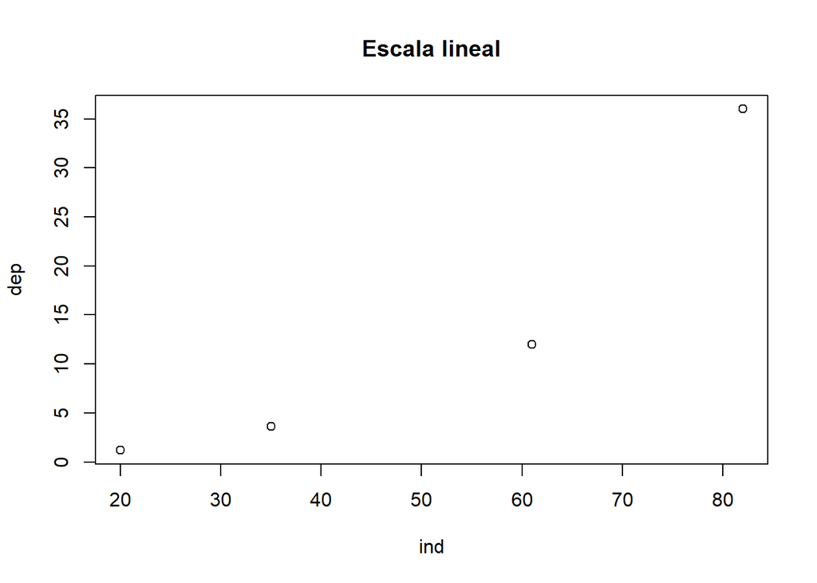

```r
#plot sin cambio de escala
plot(ind,dep, main = "Escala lineal")
```

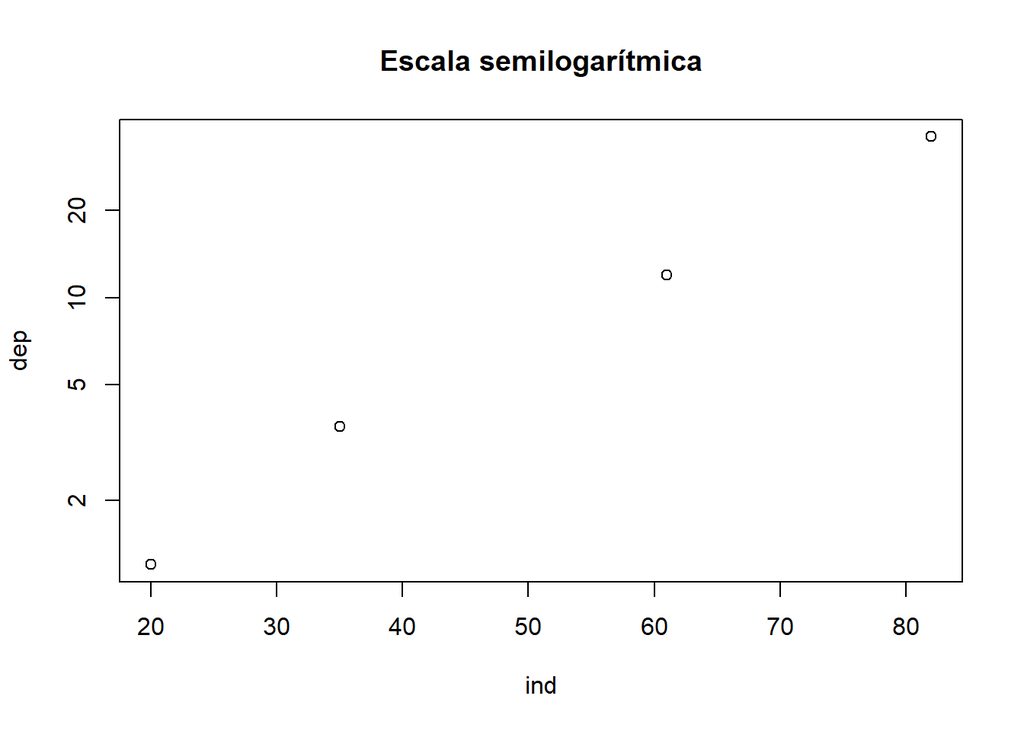

```r
#plot de escala logaritmica en eje "y"
plot(ind,dep, log = "y", main = "Escala semilogarítmica")
```

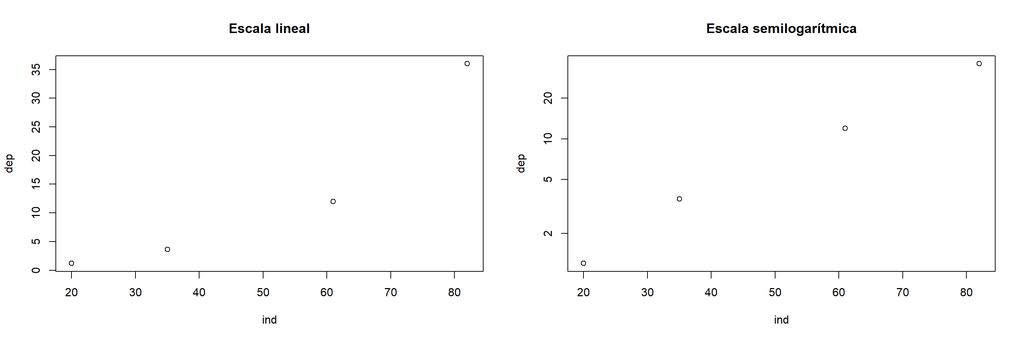

```r
#Gráficos representados en la misma figura
par(mfrow = c(1,2))
plot(ind,dep, main = "Escala lineal")
plot(ind,dep, log = "y", main = "Escala semilogarítmica")
```

```r
par(mfrow = c(1,1))
```

Hacemos el modelo lineal de transformar en logaritmo en base 10 a la variable dependiente, en función de la independiente (sin variar).

```r
#regresión lineal
lm(log10(dep)~ind)
```

```
##
## Call:
## lm(formula = log10(dep) ~ ind)
##
## Coefficients:
## (Intercept)          ind
##    -0.32951      0.02318
```

```r
#coeficiente de determinación
summary(lm(log10(dep)~ind))$r.squared
```

```
## [1] 0.9928168
```

Lo que acabamos de obtener es que $\log(dep) = 0.023\cdot ind - 0.33$ es una buena aproximación de nuestros datos.

Con lo cual, la variable dependiente se obtiene con la siguiente fórmula:

$$dep = 10^{0.023\cdot ind}\cdot10^{-0.33} = 1.054^{ind}\cdot 0.468$$

Se puede discernir que la relación existente entre la varibale dependiente e independiente es una relación de tipo exponencial.

Para observar esto, vamos a representar la nube de ptos con plot() y luego añadimos la curva de la función dictada anteriormente.

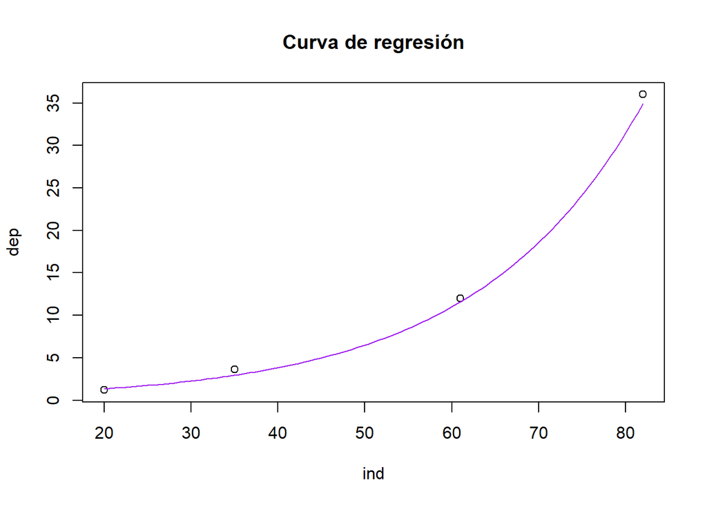

```r
plot(ind,dep, main = "Curva de regresión")
curve(1.054^x*0.468, add = TRUE, col = "purple")
```

## 1.4 Ejemplo para relaciones potenciales (escala doble logarítmica)

En este caso trabajaremos con el siguiente data frame:

```r
#Datos de estudios en forma DF
tiempo = 1:10 #variable independiente

#Variable dependiente (masa de virus o bacteria)
gramos = c(0.097,0.709,2.698,6.928,15.242,29.944,52.902,83.903,120.612,161.711)
d.f = data.frame(tiempo,gramos)
```

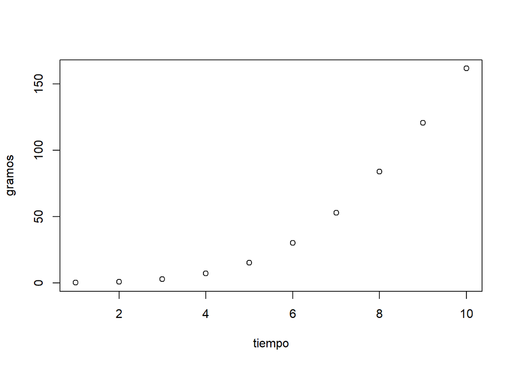

```r
#Plot normal
plot(d.f)
```

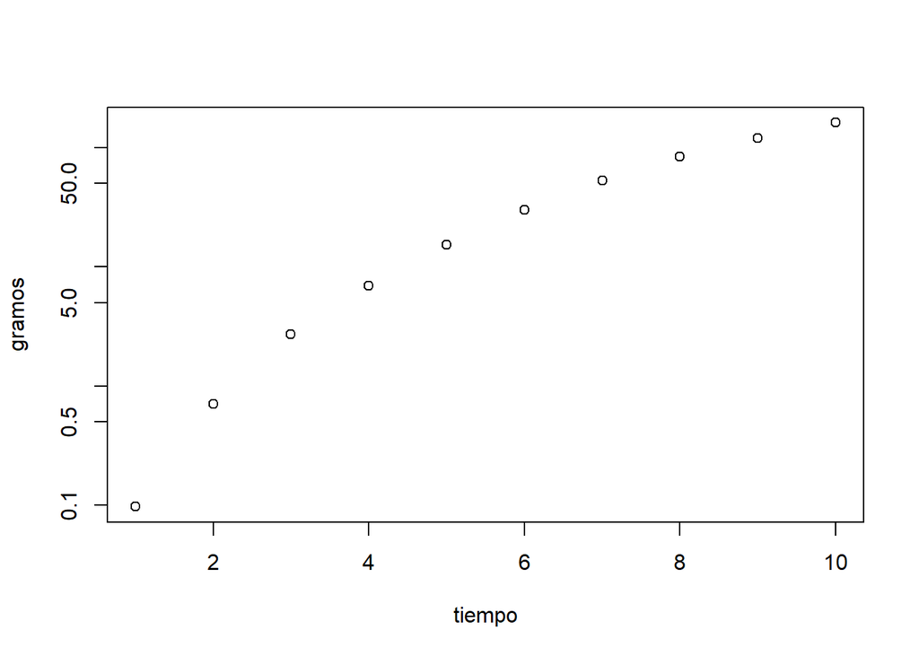

```r
#Plot semilog
plot(d.f, log = "y")
```

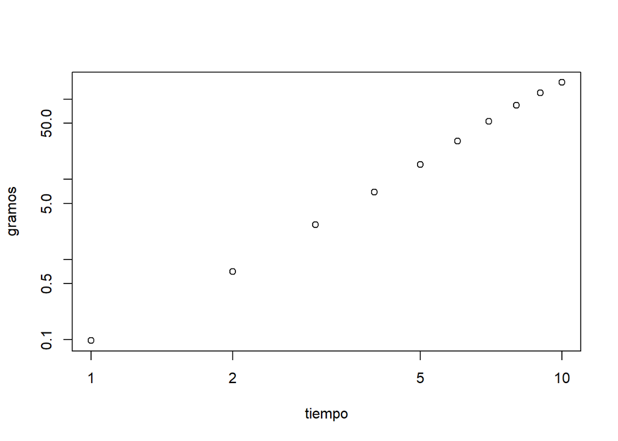

```r
#Plot doble log
plot(d.f, log = "xy")
```

Represento todos los plots en la misma figura.

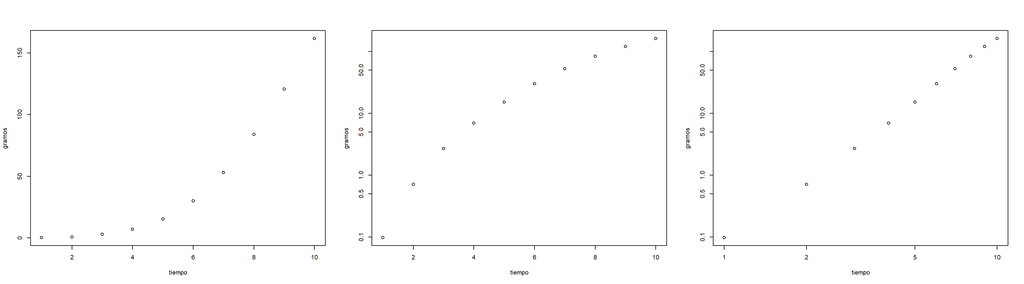

```r
par(mfrow= c(1,3))
plot(d.f)
plot(d.f, log = "y")
plot(d.f, log = "xy")
```

```r
par(mfrow= c(1,1))
```

Hacemos el modelo linea de transformar en logaritmo en base 10 a la variable dependiente, en función de la independiente (transformada a log en base 10).

```r
#regresión lineal
lm(log10(gramos)~log10(tiempo), data = d.f)
```

```
##
## Call:
## lm(formula = log10(gramos) ~ log10(tiempo), data = d.f)
##
## Coefficients:
##   (Intercept)  log10(tiempo)
##        -1.093          3.298
```

```r
#coeficiente de determinación
summary(lm(log10(gramos)~log10(tiempo), data = d.f))$r.squared
```

```
## [1] 0.9982009
```

Lo que acabamos de obtener es que:

$$\log(gramos) = 3.298\cdot \log(tiempo) - 1.093$$

Es una buena aproximación de nuestros datos (r.squared = 0.998).

Con lo cual:

$$gramos = 10^{3.298\cdot\log(tiempo)}\cdot10^{-1.093} = tiempo^{3.298}\cdot 0.081$$

Se puede discernir que la relación existente entre la varibale dependiente e independiente es una relación de tipo potencial.

Para observar esto, vamos a representar la nube de ptos con plot() y luego añadimos la curva de la función dictada anteriormente con curve().

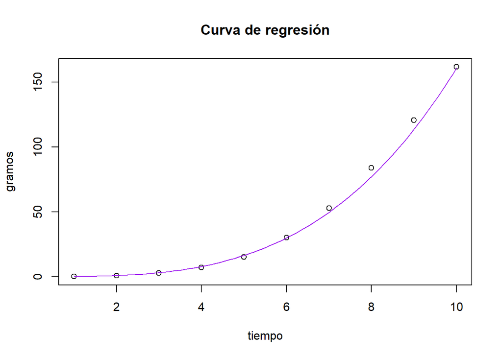

```r
plot(d.f, main = "Curva de regresión")
curve(x^(3.298)*0.081, add=TRUE, col = "purple")
```